## Interactive ggplot2 and R plots using rOpenSci, Plotly, and IPython

## *Introduction*

[Plotly](https://plot.ly) lets you collaboratively make and share beautiful, web-based plots. IPython is an interactive shell environemnt. If you're *reading* this on NBviewer and this is your URL:

> nbviewer.ipython.org/gist/msund/403910de45e282d658fa

you're looking at the style the page also looks for *writing* . You get markdown, reproducibility, and a flexible shell for coding.

It's awesome. Using the [R kernel](https://github.com/takluyver/IRkernel) with Plotly lets you make and embed interactive graphs, explain them, and edit them with others all in one place. You can edit with any language with our [APIs](https://plot.ly/api) or [our web app](https://plot.ly) .

You'll want to select CRAN you like and set up an iframe function for displaying plots.

```python
local({r <- getOption("repos")
       r["CRAN"] <- "http://cran.r-project.org"
       options(repos=r)
})
```

Now we'll install packages. Use Plotly's public sandbox (shown below), or [sign-up](https://plot.ly/ssi) . You can add your username and email and run this command: `signup("new_username", "your_email@domain.com")` to get a key.

You can use `quiet = TRUE` to prevent the stream from printing into your NB.

```python
x <- c("devtools", "WDI", "ggplot2")#WDI is World Bank Data API
install.packages(x, quiet = TRUE)
```

Install Plotly, part of the rOpenSci project for open data and science.

```python
if(!require(plotly)) {
 install_github("plotly", "ropensci", quiet = TRUE)
 }
```

```python
library(plotly,ggplot2,reshape)#needed libraries
```

You can [sign up](https://plot.ly/ssi) for free, or use our public key.

```python
py <- plotly("ggplot2examples", "3gazttckd7")#Initiate Plotly graph object
```

## I. Plotting World Bank data collaboratively with ggplot2, Python, R, and a web app

Suppose you see a lovely graph on the [World Bank website](http://blogs.worldbank.org/opendata/accessing-world-bank-data-apis-python-r-ruby-stata) . The graph uses [ggplot2](http://ggplot2.org) , a remarkable plotting library for R. You want to get the data from it, draw the graph with a log axis, and embed an interactive graph on your website.

We run the script in our RStudio (or the new [R kernel](https://github.com/takluyver/IRkernel) for IPython), add `py$ggplotly` to the call, and re-draw the ggplot2 figure in Plotly. It's drawn using D3, and adds the data to your graph at a URL: plot.ly/RgraphingAPI/1457 .

```python
library(WDI)
library(ggplot2)

#Grab GNI per capita data for Chile, Hungary and Uruguay

dat = WDI(indicator='NY.GNP.PCAP.CD', country=c('CL','HU','UY'), start=1960, end=2012)

#a quick plot with legend, title and label

wb <- ggplot(dat, aes(year, NY.GNP.PCAP.CD, color=country)) + geom_line()
+     xlab('Year') + ylab('GDI per capita (Atlas Method USD)')
+     labs(title <- "GNI Per Capita ($USD Atlas Method)")

py$ggplotly(wb)
```

```
Error in +xlab("Year"): invalid argument to unary operator
```

```
Error in +labs(title <- "GNI Per Capita ($USD Atlas Method)"): invalid argument to unary operator
```

That produces an error, but that's ok: Plotly still graphs the data. Grab the response from https://plot.ly/~RgraphingAPI , make an iframe function, and add it to your iframe.

```python
library(IRdisplay)
plotly_iframe <- function(url) {
    # set width and height from options or default square
    w <- "700"
    h <- "600"
    html <- paste("<center><iframe height=\"", h, "\" id=\"igraph\" scrolling=\"no\" seamless=\"seamless\"\n\t\t\t\tsrc=\"",
        url, "\" width=\"", w, "\" frameBorder=\"0\"></iframe></center>", sep="")
    return(html)
}
```

```python
display_html(plotly_iframe("https://plot.ly/~RgraphingAPI/1645"))
```

[interactive chart not shown]

Note: the data is called from a WDI database; if you make it with Plotly, the data is stored with the plot. I forked the data and shared it: https://plot.ly/~MattSundquist/1343 .

If you want to use Plotly's default graph look, you can remove the ggplot2 defaults then bring that data back into the Notebook. Note: we've used Python in another Notebook to remove the styling. *You can edit and add data from any language or our web GUI* .

```python
display_html(plotly_iframe("https://plot.ly/~PythonAPI/455"))
```

[interactive chart not shown]

All you need is to get the data in and then you have options, including to run stats, add fits and error bars, or share and collaborate. We edited this graph in our GUI.

```python
display_html(plotly_iframe("https://plot.ly/~MattSundquist/1404"))
```

[interactive chart not shown]

And this was also edited in the GUI.

```python
display_html(plotly_iframe("https://plot.ly/~MattSundquist/1339"))
```

[interactive chart not shown]

Then you can make a new plot, like this one made by re-using the same data and graphing it with matplotlib. This one was drawn in another [IPython Notebook](http://nbviewer.ipython.org/gist/msund/61cdbd5b22c103fffb84) .

```python
display_html(plotly_iframe("https://plot.ly/~IPython.Demo/3821/"))
```

[interactive chart not shown]

## II. Other graph options from ggplot2 and Plotly

You can use ggplot2 to make bar, line, and scatter charts. You can use Plotly’s R API to make those plus bubble, polar, contour, heatmaps, histograms, boxplots, 3D graphs, and streaming graphs. For example, here is a contour:

```python
library(plotly)
p <- plotly(username="MattSundquist", key="c6393zudwx")

size <- 100
x <- seq(-2*pi, 2*pi, length=size)
y <- seq(-2*pi, 2*pi, length=size)
z <- matrix(0, size, size)
for(i in 1:size) {
    for(j in 1:size) {
        r2 <- x[i]^2 + y[j]^2
        z[i, j] <- sin(x[i])*cos(y[j])*sin(r2)/log(r2+1)
    }
}

trace0 <- list(
  x = x,
  y = y,
  z = z,
  type = "contour"
)
response <- p$plotly(trace0, kwargs=list(filename="simple-contour", fileopt="overwrite"))

url <- response$url
filename <- response$filename
```

```python
display_html(plotly_iframe("https://plot.ly/~MattSundquist/1443"))
```

[interactive chart not shown]

## III. Bar Charts.

Let's take on a [grouped bar chart](http://stackoverflow.com/questions/18158461/grouped-bar-plot-in-ggplot) question from Stack Overflow. We'll need to use a few extra packages.

```python
install.packages("reshape", quiet = TRUE)
```

```python
library(reshape, quiet = TRUE)
```

And read in our data.

```python
raw <- read.csv("http://pastebin.com/raw.php?i=L8cEKcxS",sep=",")
raw[,2]<-factor(raw[,2],levels=c("Very Bad","Bad","Good","Very Good"),ordered=FALSE)
raw[,3]<-factor(raw[,3],levels=c("Very Bad","Bad","Good","Very Good"),ordered=FALSE)
raw[,4]<-factor(raw[,4],levels=c("Very Bad","Bad","Good","Very Good"),ordered=FALSE)

raw=raw[,c(2,3,4)] # getting rid of the "people" variable as I see no use for it

freq=table(col(raw), as.matrix(raw)) # get the counts of each factor level
```

```python
Names=c("Food","Music","People")     # create list of names
data=data.frame(cbind(freq),Names)   # combine them into a data frame
data=data[,c(5,3,1,2,4)]             # sort columns

# melt the data frame for plotting
data.m <- melt(data, id.vars='Names')

# plot everything
n <- ggplot(data.m, aes(Names, value)) +
  geom_bar(aes(fill = variable), position = "dodge", stat="identity")
  py$ggplotly(n)
```

```python
display_html(plotly_iframe("https://plot.ly/~RgraphingAPI/1649"))
```

[interactive chart not shown]

And once you have your data in Plotly, you can easily re-style the graph with the GUI. You have many options.

```python
display_html(plotly_iframe("https://plot.ly/~MattSundquist/1455"))
```

[interactive chart not shown]

Let's try a [stacked bar chart](http://stackoverflow.com/questions/21236229/ggplot2-stacked-bar-chart) .

```python
DF <- read.table(text="Rank F1     F2     F3
1    500    250    50
2    400    100    30
3    300    155    100
4    200    90     10", header=TRUE)

library(reshape2)
DF1 <- melt(DF, id.var="Rank")

library(ggplot2)
b <- ggplot(DF1, aes(x = Rank, y = value, fill = variable)) +
  geom_bar(stat = "identity")
py$ggplotly(b)
```

```python
display_html(plotly_iframe("https://plot.ly/~RgraphingAPI/1650"))
```

[interactive chart not shown]

And we can do a [dodged bar chart](http://stackoverflow.com/questions/14587335/how-to-ggplot-dodged-bar-chart-using-stat-identity) .

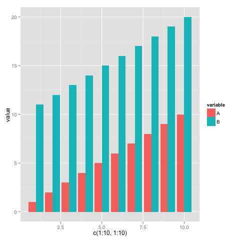

```python
d <- data.frame(A=c(1:10), B=c(11:20))
ggplot(data=data.frame(value=c(d$A, d$B), variable=c(rep("A",10),rep("B",10))), aes(x=c(1:10,1:10), y=value, fill=variable))+geom_bar(stat="identity", position="dodge")
py$ggplotly()
```

```python
display_html(plotly_iframe("https://plot.ly/~ggplot2examples/59"))
```

[interactive chart not shown]

## IV. Scatter Plots

Let's try a scatter, straight from the ggplot2 docs.

```python
dsamp <- diamonds[sample(nrow(diamonds), 1000), ]
d <- qplot(carat, price, data=dsamp, colour=clarity)
py$ggplotly()
```

```python
display_html(plotly_iframe("https://plot.ly/~ggplot2examples/42"))
```

[interactive chart not shown]

Then hide a few series and add a pair of fits.

```python
display_html(plotly_iframe("https://plot.ly/~MattSundquist/1456"))
```

[interactive chart not shown]

You can also plot with diverging color gradients.

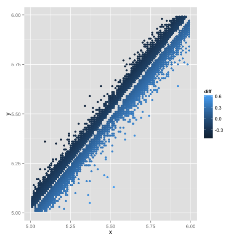

```python
dsub <- subset(diamonds, x > 5 & x < 6 & y > 5 & y < 6)
dsub$diff <- with(dsub, sqrt(abs(x-y))* sign(x-y))
(d <- qplot(x, y, data=dsub, colour=diff))
```

We could translate that one, but what about lovely muted colors? They are also great for taking in with the eyes.

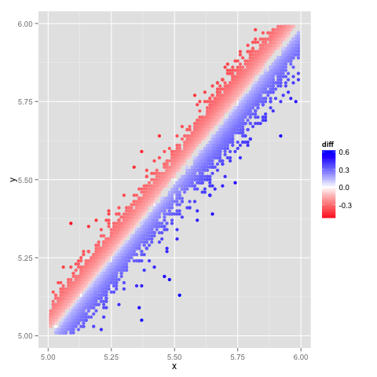

```python
library(scales) # for muted
d + scale_colour_gradient2(low="red", high="blue")
```

Style a bit in the GUI, and here we have it.

```python
display_html(plotly_iframe("https://plot.ly/~MattSundquist/1438"))
```

[interactive chart not shown]

## V. Maps

Do you like lovely maps? So do we! Check out the hover text available for this one: the bubbles are sized for the population in cities and tell you the city name on the hover. You can zoom in and then double click to re-size.

```python
data(us.cities, package="maps")
viz <- ggplot(us.cities, aes(long, lat)) +
 borders(regions="us", name="borders") +
 coord_equal() +
 geom_point(aes(text=name, size=pop), colour="blue", alpha=1/2, name="cities")
```

```python
py$ggplotly()
```

```python
display_html(plotly_iframe("https://plot.ly/~MattSundquist/1461"))
```

[interactive chart not shown]

## VI. Roadmap and getting in touch

Next on our roadmap is:

- More ggplot2 support.
- GET requests so you can call data directly from a grid.
- Static image generation from the API.
- GUI and API plotting inside the R Studio Viewer.
- Automatically embedding graphs in IPython NB for R.
- Streaming and 3D for R (See streaming and 3D for Python).

Does this cover it for you? Feel free to get in touch at feedback [at] plot [dot] ly, on [GitHub](https://github.com/ropensci/plotly) , or @plotlygraphs .